# Introducción a R y Rstudio para ciencias de la salud

Dr. Jorge Schleef

# ¿Qué es R?

Es un **lenguaje de programación** y **entorno** para la computación estadística y gráficos.

[figure not shown]

# Razones para usar R

- Programa gratuito y de fuente abierta.
- Acceso a herramientas de análisis de datos **especializadas**.
- Automatización de tareas que demandan tiempo.
- Transparencia y reproductibilidad.

# Ejemplo

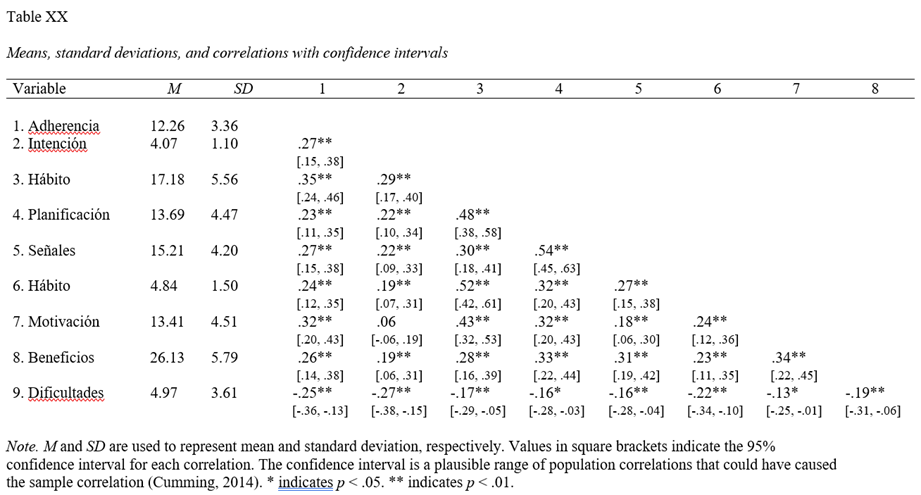

# ¿Cómo descargar R?

R se puede descargar desde http://cran.r-project.org/bin/windows/base/.

[figure not shown]

Para facilitar el trabajo con R típicamente se utiliza un entorno de desarrollo integrado (*Integrated Development Environment*, IDE) denominado **Rstudio**.

# Rstudio

Descargar:

https://posit.co/download/rstudio-desktop/

[figure not shown]

# Interface Rstudio

[figure not shown]

# ¿Cómo funciona R?

Cualquier elemento que ingresa y se manipula dentro de R se denomina **objeto**.

Los objetos pueden ir desde elementos simples (números o palabras) a otros más complejos (tablas, gráficos, bases de datos, resultados de análisis estadísticos).

En R, los objetos se definen con el **operador de asignación** “<-”.

```r
suma <- 2 +2
```

El hecho de escribir posteriormente **suma** arrojará el contenido del objeto.

```r
suma
```

```
## [1] 4
```

# Otro ejemplo

El siguiente código asigna diferentes números a los objetos **a** y **b**, y luego asigna la correlación de Pearson entre ambos conjuntos de números a un nuevo objeto llamado **asociación**.

```r
a <- c(1, 53, 69, 20, 67, 32, 75, 83)
b <- c(2, 43, 89, 30, 50, 18, 89, 60)

asociacion <- cor.test(x = a,
                       y = b)
```

Escribir ahora el nombre del objeto **asociacion** devolverá la correlación de Pearson calculada e información adicional.

```r
asociacion
```

```
##
##  Pearson's product-moment correlation
##
## data:  a and b
## t = 4.2191, df = 6, p-value = 0.005567
## alternative hypothesis: true correlation is not equal to 0
## 95 percent confidence interval:
##  0.4100050 0.9751937
## sample estimates:
##       cor
## 0.8648158
```

Los objetos también se pueden **actualizar**. Para agregar un nuevo número al objeto **a** simplemente se añade dentro de la secuencia (**96**).

```r
a <- c(1, 53, 69, 20, 67, 32, 75, 83, 96)

a
```

```
## [1]  1 53 69 20 67 32 75 83 96
```

# Funciones

Los objetos se manipulan usando **funciones** que transforman **datos de entrada** (input) en una **salida** (output).

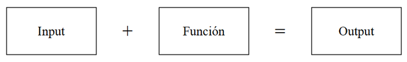

Para usar una función se escribe su **nombre** seguido por **()**.

Por ejemplo, la función **median()** calcula la mediana de un conjunto de datos numéricos.

```r
median(a)
```

```
## [1] 67
```

```r
median(b)
```

```
## [1] 46.5
```

Las funciones se aplican sobre los elementos que se incluyen al interior del paréntesis.

El comando anterior le dice a R “calcula la mediana del objeto **a**”, que incluye un conjunto de números.

# Función c()

Une un conjunto de datos.

Los números 28, 18, 25, 42, 54 y 33 por sí solos no representan un conjunto dentro de R, sin embargo, esto se puede establecer usando **c()**.

```r
c(28, 18, 25, 42, 54, 33)
```

```
## [1] 28 18 25 42 54 33
```

Automáticamente R devuelve los números que están en el conjunto.

Sin embargo, esto **no** ocurre cuando el resultado de la función se asigna a un objeto.

```r
a <- c(28, 18, 25, 42, 54, 33)
```

En este caso, es necesario escribir el nombre del objeto para obtener su contenido.

```r
a
```

```
## [1] 28 18 25 42 54 33
```

Lo anterior aplica para cualquier función.

# cor.test()

Esta función permite obtener el coeficiente de correlación para dos variables incluyendo su valor *p* e intervalos de confianza al 95%.

```r
a <- c(1, 53, 69, 20, 67, 32, 75, 83)
b <- c(2, 43, 89, 30, 50, 18, 89, 60)

asociacion <- cor.test(x = a,
                       y = b)

asociacion
```

```
##
##  Pearson's product-moment correlation
##
## data:  a and b
## t = 4.2191, df = 6, p-value = 0.005567
## alternative hypothesis: true correlation is not equal to 0
## 95 percent confidence interval:
##  0.4100050 0.9751937
## sample estimates:
##       cor
## 0.8648158
```

# Paquetes/librerías

Tanto **c()** como **cor.test()** son funciones que vienen integradas al instalar R (R base).

Para tareas más especializadas se necesitan **paquetes (librerías)** que agregan nuevas funciones a R.

Estos paquetes se almacenan en el **CRAN (Comprehensive R Archive Network)** dentro de https://www.r-project.org/.

Los paquetes del CRAN son **revisados por pares**, por lo que pueden ser citados en publicaciones científicas. Además, están sujetos a mantención y tienen un manual de referencia.

Se descarga e instala un nuevo paquete utilizando la función **install.library(“nombre_paquete”)**.

# Resumen

Generalmente, cargaremos una base de datos en formato Excel o SPSS como un nuevo objeto dentro de R, y aplicaremos funciones sobre las columnas (variables) para obtener información relevante.

# Argumentos en una función

Las funciones suelen tener una **configuración por defecto**, pero también es posible **controlar algunos de sus parámetros**.

Los parámetros de una función se denominan **argumentos**.

Por ejemplo, la función **cor.test()** calcula automáticamente el coeficiente de correlación de Pearson.

No obstante, con el argumento **method** se puede ajustar la función para obtener el coeficiente de correlación de Spearman.

```r
a <- c(1, 53, 69, 20, 67, 32, 75, 83)
b <- c(2, 43, 89, 30, 50, 18, 89, 60)

cor.test(x = a,
         y = b,
         method = "spearman")
```

```
##
##  Spearman's rank correlation rho
##
## data:  a and b
## S = 8.5495, p-value = 0.002439
## alternative hypothesis: true rho is not equal to 0
## sample estimates:
##       rho
## 0.8982197
```

# Interfaz de Rstudio

[figure not shown]

- **Script:** hoja donde escribes los códigos que quieres registrar y ejecutar.

Para ejecutar un código selecciónalo y presiona **Run**, o usa **ctrl + enter**.

- **Consola:** ventana donde se muestran los resultados de ejecutar un código.
- **Entorno:** almacena los objetos importados o creados en R.

Para seguir utilizando la información generada por una función en otras operaciones, se necesita asignar el resultado a un objeto.

```r
# No será recordado en tareas posteriores dentro de R

c(1, 53, 69, 20, 67, 32, 75, 83)
```

```
## [1]  1 53 69 20 67 32 75 83
```

```r
# El conjunto será almacenado y podrá ser utilizado posteriormente

conjunto_num <- c(1, 53, 69, 20, 67, 32, 75, 83)

# Suma 100 a cada número del objeto "conjunto_num"

conjunto_num + 100
```

```
## [1] 101 153 169 120 167 132 175 183
```

- **Visor de gráficos:** proyecta los gráficos creados.

La función **hist()** crea un histograma.

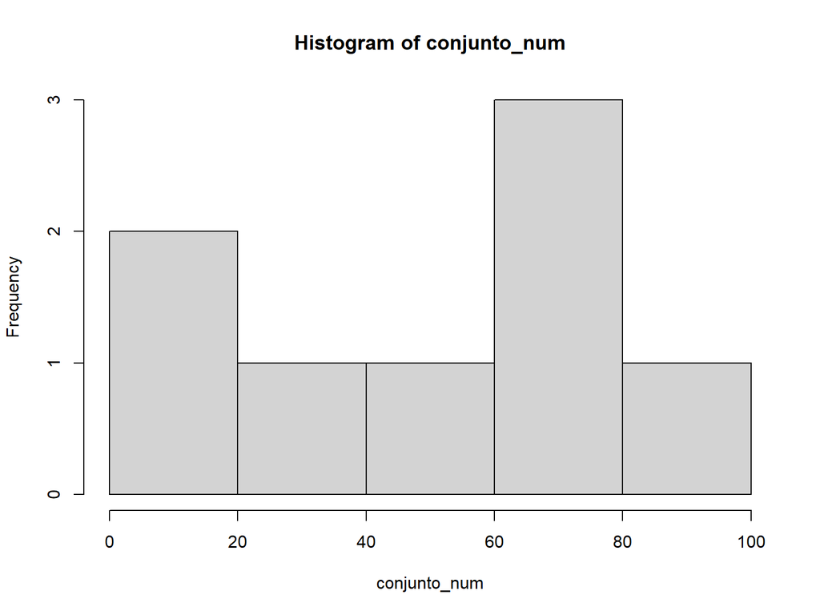

```r
hist(conjunto_num)
```

# Tipos de variables en R

- En R, las variables **cualitativas** (columnas que utilizan etiquetas) se denominan **character** (**chr**).

Cualquier variable que incluya datos de texto se convertirá automáticamente a **chr** dentro de R.

- Las variables **cuantitativas** se denominan usualmente **numeric** (**num**). Existen otros formatos para variables con datos numéricos como **dbl** (números con decimales) o **int** (números enteros).

# Atajos en R

- “**Alt + -**” operador de asignación.
- “**ctrl + enter**” correr código.
- “**ctrl + l**” limpiar consola.